# 1 Impacto de la eliminación de réplicas y puntos centrales en diseños factoriales completos $2^k$

**Nota**

El presente documento corresponde a un apartado del trabajo titulado *“Guía para la implementación de diseños experimentales en la industria farmacéutica”*, presentado por Nathalia Cortés Duque como requisito para optar al título de *Magíster en Ciencias - Estadística* de la Universidad Nacional de Colombia.

# 2 *Metodología*

## 2.1 Evaluación de la significancia de los efectos

El presente estudio tiene como propósito analizar el impacto de eliminar réplicas o los puntos centrales en un diseño factorial completo $2^k$ sobre la significancia estadística de los efectos principales e interacciones, así como sobre el error cuadrático medio (ECM). Para este fin se realizaron 1000 simulaciones independientes, y en cada simulación se generó un caso particular de efectos activos y su correspondiente respuesta.

En cada simulación se genera un vector con todos los factores y sus interacciones del respectivo diseño factorial completo $2^k$ los cuales se agrupan en el vector `todos_efectos`, así:

| Diseño factorial | Número de efectos | Efectos |
| --- | --- | --- |
| $2^2$ | 3 | A, B, AB |
| $2^3$ | 7 | A, B, C, AB, AC, BC, ABC |
| $2^4$ | 15 | A, B, C, D, AB, AC, AD, BC, BD, CD, ABC, ABD, ACD, BCD, ABCD |
| $2^5$ | 31 | A, B, C, D, E, AB, AC, AD, AE, BC, BD, BE, CD, CE, DE, ABC, ABD, ABE, ACD, ACE, ADE, BCD, BCE, BDE, CDE, ABCD, ABCE, ABDE, ACDE, BCDE, ABCDE |

A partir de este conjunto, se selecciona aleatoriamente un número aleatorio de efectos que serán considerados significativos; dichos efectos se denominan `efectos activos`. A estos efectos se les asigna un valor aleatorio tomado de una distribución uniforme en el intervalo $[−7,-0.5]$ y $[0.5, 7]$, mientras que los demás mantienen valor cero. De esta forma se construye el vector `efectos_reales_vec`, que refleja cuáles efectos son diferentes de cero. Posteriormente, la información se almacena en la tabla `efectos_reales`, que guarda en forma binaria (1/0) cuáles factores fueron definidos como significativos.

Se genera un diseño factorial $2^k$ con dos réplicas y cinco puntos centrales (`dis1_cod`). A este diseño se le asigna una respuesta (`yrta`) calculada en función de los efectos previamente definidos, es decir, se multiplican los valores de los factores y sus interacciones por los coeficientes correspondientes en `efectos_reales_vec`, más un término de error aleatorio `error` con distribución normal $(\mu = 0, \sigma^2 = 2^2)$. Como resultado, los factores seleccionados como activos aportan un efecto distinto de cero, mientras que los demás se anulan. La respuesta final se obtiene sumando estos efectos y el error a una constante de 50.

Este diseño inicial se emplea para construir otras tres variantes eliminando, de manera aleatoria, filas correspondientes a réplicas o puntos centrales: un diseño con réplicas pero sin puntos centrales (`dis2_cod`), un diseño sin réplicas y con cinco puntos centrales (`dis3_cod`) y un diseño sin réplicas con dos puntos centrales (`dis4_cod`)

Para cada diseño se ajusta el modelo completo (`mod1 <- lm(yrta~A*B, data=dis1_cod)`), considerando tanto los efectos principales como las interacciones, y se calcula el ANOVA correspondiente:

*Diseño factorial completo* $2^2$:

$$Y \;=\; \beta_0 \;+\; \beta_1 X_1 \;+\; \beta_2 X_2 \;+\; \beta_{12}X_1X_2 \;+\; \varepsilon,
\quad \varepsilon \sim \mathcal{N}(\mu = 0, \sigma^2 = 2^2)$$

*Diseño factorial completo* $2^3$:

$$Y = \beta_0
+ \sum_{i=1}^{3} \beta_i X_i
+ \sum_{i<j}^{3} \beta_{ij} X_i X_j
+ \beta_{123} X_1 X_2 X_3
+ \varepsilon,
\quad i = 1,2,3;\;\; j = 1,2,3;
\quad \varepsilon \sim N(\mu = 0, \sigma^2 = 2^2)$$

*Diseño factorial completo* $2^4$:

$$Y = \beta_0
+ \sum_{i=1}^{4} \beta_i X_i
+ \sum_{i<j}^{4} \beta_{ij} X_i X_j
+ \sum_{i<j<k}^{4} \beta_{ijk} X_i X_j X_k
+ \beta_{1234}\, X_1 X_2 X_3 X_4
+ \varepsilon$$

donde,

$$i,j,k \in \{1,2,3,4\},\;\; \varepsilon \sim \mathcal{N}(\mu = 0, \sigma^2 = 2^2)$$

*Diseño factorial completo* $2^5$:

$$Y = \beta_0
+ \sum_{i=1}^{5} \beta_i X_i
+ \sum_{i<j}^{5} \beta_{ij} X_i X_j
+ \sum_{i<j<k}^{5} \beta_{ijk} X_i X_j X_k
+ \sum_{i<j<k<l}^{5} \beta_{ijkl} X_i X_j X_k X_l
+ \beta_{12345}\, X_1 X_2 X_3 X_4 X_5
+ \varepsilon$$

donde,

$$i,j,k,l \in \{1,2,3,4,5\},\;\; \varepsilon \sim \mathcal{N}(\mu = 0, \sigma^2 = 2^2)$$

Con los resultados de significancia de los efectos se almacenan en las tablas `TAB1_22`, `TAB2_22`y `TAB3_22`, donde el valor 1 indica significancia estadística ($p < 0.05$) y 0 indica no significancia. Este procedimiento se implementa evaluando, en cada fila del ANOVA, si el valor $p$ es menor o igual a 0.05, transformando el resultado lógico en un valor entero.

A partir de estas tablas se calcula el *porcentaje de concordancia* entre los efectos reales y los detectados por cada modelo, la *potencia* (proporción de efectos verdaderamente significativos correctamente identificados) y el *error tipo I* (proporción de efectos nulos detectados como significativos).

## 2.2 Evaluación del ECM con medidas repetidas

Con relación a la evaluación del ECM, se utiliza la metodología de medidas repetidas, en la cual a una misma unidad experimental se le aplican sucesivamente varios tratamientos, generando valores repetidos de la respuesta sobre el mismo individuo (Dı́az Monroy y Mario Alfonso (2012)).

En este estudio, a partir de los diseños simulados en la sección anterior, cada fila corresponde a la simulación del diseño experimental de referencia (`dis1_cod`), al que se le generan variantes al eliminar réplicas o puntos centrales (`dis2_cod`, `dis3_cod`, `dis4_cod`). Para cada diseño se obtiene como variable respuesta el Error Cuadrático Medio (ECM), calculado mediante la siguiente fórmula:

$$\text{ECM} = \frac{\text{deviance}(modelo)}{\text{grados de libertad del residual}(modelo)}.$$

Asimismo, es posible considerar una matriz de contrastes generales de interés $C_2$, tales como:

$$C_2 =
\begin{bmatrix}
-1 & -1 & 1 & 1 \\
-1 & 1 & 1 & 1 \\
1 & -1 & 0 & 0
\end{bmatrix}$$

Donde los contrastes a evaluar son:

*Contraste 1:* Contraste que relaciona los diseños con réplica con respecto a los diseños sin réplica $C_1 =$ (-1, -1, 1, 1)

*Contraste 2:* Contraste que relaciona el diseño con réplica y 5 puntos centrales frente al conjunto de variantes derivadas del mismo $C_2 =$ (-1, 1, 1, 1)

La matriz $C$ se utiliza para transformar los datos: $Y = CX$. De esta forma, el problema se reduce a $(p-1)$ dimensiones y se trabaja con contrastes independientes, evitando dependencia entre medias y permitiendo aplicar la prueba $T^2$ de Hotelling.

El cálculo implementado en el código sigue la formulación teórica:

$$T^2 = n(C \overline{X})' (CSC')^{-1} (C \overline{X}),$$

donde $n$ es el número de simulaciones y $S$ la matriz de covarianzas estimada mediante

$$S = \frac{1}{n-1}X'(I - \tfrac{1}{n}\mathbf{1}\mathbf{1}')X.$$

La decisión es rechazar $H_0$ si, para un nivel de significancia $\alpha = 0.05$,

$$F = \frac{n - p + 1}{(n-1)(p-1)} T^2 > F_{(\alpha, p-1, n-p+1)}$$

# 3 *Código*

```
Librerías requeridas: dplyr, flextable, tidyr, ggplot2, DoE.base
```

## 3.1 Diseño $2^2$

### 3.1.1 Significancia de los efectos

**Código**

```r
# Matrices
TAB1_22 <- matrix(0, nrow = n, ncol = 3)
TAB2_22 <- matrix(0, nrow = n, ncol = 3)
TAB3_22 <- matrix(0, nrow = n, ncol = 3)
TAB4_22 <- matrix(0, nrow = n, ncol = 3)
TAB6_22 <- matrix(0, nrow = n, ncol = 3)
efectos_reales_22 <- matrix(NA, nrow = n, ncol = 3)

names_22 <- c("A","B", "A:B")
colnames(TAB1_22) <- names_22
colnames(TAB2_22) <- names_22
colnames(TAB3_22) <- names_22
colnames(TAB4_22) <- names_22
colnames(TAB6_22) <- names_22
colnames(efectos_reales_22) <- names_22

# Tabla para completar los errores
ECM_tab_22 <- data.frame(
    dis1_22 = numeric(n),
    dis2_22 = numeric(n),
    dis3_22 = numeric(n),
    dis4_22 = numeric(n))

# Bucle principal
set.seed(3)
for(i in seq_len(n)){
  ## Efectos a evaluar en el este diseño
  todos_efectos_22 <- c("A", "B", "A:B")

  # Selección de un número aleatorio entre 1 y 3
  # dado que existen 3 efectos posibles a evaluar en este diseño.
  n_ef <- sample(0:length(todos_efectos_22), 1)

  # Elección aleatoria _n_ef_ efectos que serán los efectos significativos
  efectos_activos <- sample(todos_efectos_22, n_ef)
  efectos_reales_22_vec <- setNames(rep(0, length(todos_efectos_22)), todos_efectos_22)

  # Asignación de un valor aleatorio a los efectos elegidos como significativos:
  efectos_reales_22_vec[efectos_activos] <- sample(c(runif(n_ef, -7, -0.5),
                                                  runif(n_ef,  0.5, 7)),n_ef)

  # Guardar efectos reales como 1/0
  efectos_reales_22[i,] <- c(
    as.integer(efectos_reales_22_vec["A"]   != 0),
    as.integer(efectos_reales_22_vec["B"]   != 0),
    as.integer(efectos_reales_22_vec["A:B"]  != 0))

  # Generar respuesta

  ## Diseño con réplicas y con 5 puntos centrales

  dis1_cod <- data.frame(
    A = c(rep(c(-1,1),2), rep(c(-1,1),2), rep(0,5)),
    B = c(rep(c(rep(-1,2), rep(1,2)), 2), rep(0,5)))

  n_corridas <- nrow(dis1_cod)

  ## Generación del error
  error <- rnorm(n_corridas, 0, 2)               #error ~ (mu = 0, sigma^2 = 2^2)

  ## Generación de la respuesta
  yrta <- 50 +
    efectos_reales_22_vec["A"]   * dis1_cod$A +
    efectos_reales_22_vec["B"]   * dis1_cod$B +
    efectos_reales_22_vec["A:B"]  * dis1_cod$A * dis1_cod$B +
    error

  ## Asignación de la respuesta al dis1_cod
  dis1_cod <- cbind(dis1_cod, yrta)

  ## Diseño con réplicas y sin puntos centrales

  dis2_cod <- dis1_cod[-c(9:13),]

  ## Diseño sin réplica y con cinco puntos centrales
  rep1 <- c(1:4)
  rep2 <- c(5:8)
  seleccion_name <- sample(c("rep1","rep2"),1)   #repetición a eliminar
  sel <- get(seleccion_name)

  dis3_cod <- dis1_cod[-sel,]

  ## Diseño sin réplica y con dos puntos centrales
  rep1 <- c(1:4)
  rep2 <- c(5:8)
  seleccion_name <- sample(c("rep1","rep2"),1)   #repetición a eliminar
  sel <- get(seleccion_name)
  rep_pc <- sample(c(9:13),3)                    #punto central a eliminar

  dis4_cod <- dis1_cod[-c(sel,rep_pc),]

  ## Diseño sin réplica y sin puntos centrales
  rep1 <- c(1:4, 9:13)
  rep2 <- c(5:8, 9:13)
  seleccion_name <- sample(c("rep1","rep2"),1)   #repetición a eliminar
  sel <- get(seleccion_name)

  dis6_cod <- dis1_cod[-sel,]

  mod6 <- lm(yrta~A*B, data=dis6_cod)

  graf <- suppressMessages(halfnormal(mod6, alpha = 0.05, plot=FALSE, method="Lenth"))
  signif <- graf$signif
  TAB6_22[i, todos_efectos_22 %in% signif] <- 1

  # Modelo
  ## Evaluación del diseño con réplicas y con cinco puntos centrales
  mod1 <- lm(yrta~A*B, data=dis1_cod)
  ## Evaluación del diseño con réplicas y sin puntos centrales
  mod2 <- lm(yrta~A*B, data=dis2_cod)
  ## Evaluación del diseño sin réplicas y con cinco puntos centrales
  mod3 <- lm(yrta~A*B, data=dis3_cod)
  ## Evaluación del diseño sin réplicas y con dos puntos centrales
  mod4 <- lm(yrta~A*B, data=dis4_cod)

  ## Almacenar los ECM
  ECM_tab_22$dis1_22[i] <- (deviance(mod1) / df.residual(mod1))
  ECM_tab_22$dis2_22[i] <- (deviance(mod2) / df.residual(mod2))
  ECM_tab_22$dis3_22[i] <- (deviance(mod3) / df.residual(mod3))
  ECM_tab_22$dis4_22[i] <- (deviance(mod4) / df.residual(mod4))

  # Lista de modelos y de tablas
  mods <- list(mod1, mod2, mod3, mod4)
  tabs <- list(TAB1_22, TAB2_22, TAB3_22, TAB4_22)

  for (j in seq_along(mods)) {
    tabs[[j]][i, ] <- sapply(1:3, function(k) {
    as.integer(anova(mods[[j]])[k, 5] <= 0.05) })}

  ## Evaluación del diseño con réplicas y con cinco puntos centrales
  TAB1_22 <- tabs[[1]]
  ## Evaluación del diseño con réplicas y sin puntos centrales
  TAB2_22 <- tabs[[2]]
  ## Evaluación del diseño sin réplicas y con cinco puntos centrales
  TAB3_22 <- tabs[[3]]
  ## Evaluación del diseño sin réplicas y con dos puntos centrales
  TAB4_22 <- tabs[[4]]}
```

### 3.1.2 Potencia y error tipo I

**Código**

```r
## Evaluación del diseño con réplicas y con cinco puntos centrales
comp1_22 <- round(colSums(efectos_reales_22 == TAB1_22) / n * 100, 2)
pot1_22 <- round(colSums((efectos_reales_22 == 1) & (TAB1_22 == 1)) /
                colSums(efectos_reales_22 == 1) * 100, 2)
err1_22 <- round(colSums((efectos_reales_22 == 0) & (TAB1_22 == 1)) /
                colSums(efectos_reales_22 == 0) * 100, 2)

## Evaluación del diseño con réplicas y sin puntos centrales
comp2_22 <- round(colSums(efectos_reales_22 == TAB2_22) / n * 100, 2)
pot2_22 <- round(colSums((efectos_reales_22 == 1) & (TAB2_22 == 1)) /
                colSums(efectos_reales_22 == 1) * 100, 2)
err2_22 <- round(colSums((efectos_reales_22 == 0) & (TAB2_22 == 1)) /
                colSums(efectos_reales_22 == 0) * 100, 2)

## Evaluación del diseño sin réplicas y con cinco puntos centrales
comp3_22 <- round(colSums(efectos_reales_22 == TAB3_22) / n * 100, 2)
pot3_22 <- round(colSums((efectos_reales_22 == 1) & (TAB3_22 == 1)) /
                colSums(efectos_reales_22 == 1) * 100, 2)
err3_22 <- round(colSums((efectos_reales_22 == 0) & (TAB3_22 == 1)) /
                colSums(efectos_reales_22 == 0) * 100, 2)

## Evaluación del diseño sin réplicas y con dos puntos centrales
comp4_22 <- round(colSums(efectos_reales_22 == TAB4_22) / n * 100, 2)
pot4_22 <- round(colSums((efectos_reales_22 == 1) & (TAB4_22 == 1)) /
                colSums(efectos_reales_22 == 1) * 100, 2)
err4_22 <- round(colSums((efectos_reales_22 == 0) & (TAB4_22 == 1)) /
                colSums(efectos_reales_22 == 0) * 100, 2)

## Evaluación del diseño sin réplica y sin puntos centrales
comp6_22 <- round(colSums(efectos_reales_22 == TAB6_22) / n * 100, 2)
pot6_22 <- round(colSums((efectos_reales_22 == 1) & (TAB6_22 == 1)) /
                colSums(efectos_reales_22 == 1) * 100, 2)
err6_22 <- round(colSums((efectos_reales_22 == 0) & (TAB6_22 == 1)) /
                colSums(efectos_reales_22 == 0) * 100, 2)
```

## 3.2 Diseño $2^3$

### 3.2.1 Significancia de los efectos

**Código**

```r
# Matrices
TAB1_23 <- matrix(0, nrow = n, ncol = 7)
TAB2_23 <- matrix(0, nrow = n, ncol = 7)
TAB3_23 <- matrix(0, nrow = n, ncol = 7)
TAB4_23 <- matrix(0, nrow = n, ncol = 7)
TAB6_23 <- matrix(0, nrow = n, ncol = 7)
efectos_reales_23 <- matrix(0, nrow = n, ncol = 7)

names_23 <- c("A","B","C","A:B","A:C","B:C","A:B:C")
colnames(TAB1_23) <- names_23
colnames(TAB2_23) <- names_23
colnames(TAB3_23) <- names_23
colnames(TAB4_23) <- names_23
colnames(TAB6_23) <- names_23
colnames(efectos_reales_23) <- names_23

# Tabla para completar los errores
ECM_tab_23 <- data.frame(
    dis1_23 = numeric(n),
    dis2_23 = numeric(n),
    dis3_23 = numeric(n),
    dis4_23 = numeric(n))

# Bucle principal
set.seed(3)
for(i in seq_len(n)){
  ## Efectos a evaluar en el este diseño
  todos_efectos_23 <- c("A","B","C","A:B","A:C","B:C","A:B:C")

  # Selección de un número aleatorio entre 1 y 7
  # dado que existen 7 efectos posibles a evaluar en este diseño.
  n_ef <- sample(0:length(todos_efectos_23), 1)

  # Elección aleatoria _n_ef_ efectos que serán los efectos significativos
  efectos_activos <- sample(todos_efectos_23, n_ef)
  efectos_reales_23_vec <- setNames(rep(0, length(todos_efectos_23)), todos_efectos_23)

  # Asignación de un valor aleatorio a los efectos elegidos como significativos:
  efectos_reales_23_vec[efectos_activos] <- sample(c(runif(n_ef, -7, -0.5),
                                                  runif(n_ef,  0.5, 7)),n_ef)

  # Guardar efectos reales como 1/0
  efectos_reales_23[i,] <- c(
    as.integer(efectos_reales_23_vec["A"]     != 0),
    as.integer(efectos_reales_23_vec["B"]     != 0),
    as.integer(efectos_reales_23_vec["C"]     != 0),
    as.integer(efectos_reales_23_vec["A:B"]   != 0),
    as.integer(efectos_reales_23_vec["A:C"]   != 0),
    as.integer(efectos_reales_23_vec["B:C"]   != 0),
    as.integer(efectos_reales_23_vec["A:B:C"] != 0))

  # Generar respuesta

  ## Diseño de variables codificadas con réplicas y con 5 puntos centrales

  dis1_cod <- data.frame(
    A = c(rep(c(-1,1),4), rep(c(-1,1),4), rep(0,5)),
    B = c(rep(c(rep(-1,2), rep(1,2)), 4), rep(0,5)),
    C = c(rep(-1,4), rep(1,4), rep(-1,4), rep(1,4), rep(0,5)))

  n_corridas <- nrow(dis1_cod)

  ## Generación del error
  error <- rnorm(n_corridas, 0, 2)       #error ~ (mu = 0, sigma^2 = 2^2)

  ## Generación de la respuesta
  yrta <- 50 +
    efectos_reales_23_vec["A"]     * dis1_cod$A +
    efectos_reales_23_vec["B"]     * dis1_cod$B +
    efectos_reales_23_vec["C"]     * dis1_cod$C +
    efectos_reales_23_vec["A:B"]   * dis1_cod$A * dis1_cod$B +
    efectos_reales_23_vec["A:C"]   * dis1_cod$A * dis1_cod$C +
    efectos_reales_23_vec["B:C"]   * dis1_cod$B * dis1_cod$C +
    efectos_reales_23_vec["A:B:C"] * dis1_cod$A * dis1_cod$B * dis1_cod$C +
    error

  ## Asignación de la respuesta al dis1_cod
  dis1_cod <- cbind(dis1_cod, yrta)

  ## Diseño con réplicas y sin puntos centrales

  dis2_cod <- dis1_cod[-c(17:21),]

  ## Diseño sin réplica y con cinco puntos centrales
  rep1 <- c(1:8)
  rep2 <- c(9:16)
  seleccion_name <- sample(c("rep1","rep2"),1)   #repetición a eliminar
  sel <- get(seleccion_name)

  dis3_cod <- dis1_cod[-sel,]

  ## Diseño sin réplica y con dos puntos centrales
  rep1 <- c(1:8)
  rep2 <- c(9:16)
  seleccion_name <- sample(c("rep1","rep2"),1)   #repetición a eliminar
  sel <- get(seleccion_name)
  rep_pc <- sample(c(17:21),3)                   #punto central a eliminar

  dis4_cod <- dis1_cod[-c(sel,rep_pc),]

  ## Diseño sin réplica y sin puntos centrales
  rep1 <- c(1:8, 17:21)
  rep2 <- c(9:16, 17:21)
  seleccion_name <- sample(c("rep1","rep2"),1)   #repetición a eliminar
  sel <- get(seleccion_name)

  dis6_cod <- dis1_cod[-sel,]

  mod6 <- lm(yrta~A*B*C, data=dis6_cod)

  graf <- suppressMessages(halfnormal(mod6, alpha = 0.05, plot=FALSE, method="Lenth"))
  signif <- graf$signif
  TAB6_23[i, todos_efectos_23 %in% signif] <- 1

  # Modelo
  ## Evaluación del diseño con réplicas y con cinco puntos centrales
  mod1 <- lm(yrta~A*B*C, data=dis1_cod)
  ## Evaluación del diseño con réplicas y sin puntos centrales
  mod2 <- lm(yrta~A*B*C, data=dis2_cod)
  ## Evaluación del diseño sin réplicas y con cinco puntos centrales
  mod3 <- lm(yrta~A*B*C, data=dis3_cod)
  ## Evaluación del diseño sin réplicas y con dos puntos centrales
  mod4 <- lm(yrta~A*B*C, data=dis4_cod)

  ## Almacenar los ECM
  ECM_tab_23$dis1_23[i] <- (deviance(mod1) / df.residual(mod1))
  ECM_tab_23$dis2_23[i] <- (deviance(mod2) / df.residual(mod2))
  ECM_tab_23$dis3_23[i] <- (deviance(mod3) / df.residual(mod3))
  ECM_tab_23$dis4_23[i] <- (deviance(mod4) / df.residual(mod4))

  # Lista de modelos y de tablas
  mods <- list(mod1, mod2, mod3, mod4)
  tabs <- list(TAB1_23, TAB2_23, TAB3_23, TAB4_23)

  for (j in seq_along(mods)) {
    tabs[[j]][i, ] <- sapply(1:7, function(k) {
    as.integer(anova(mods[[j]])[k, 5] <= 0.05) })}

  ## Evaluación del diseño con réplicas y con cinco puntos centrales
  TAB1_23 <- tabs[[1]]
  ## Evaluación del diseño con réplicas y sin puntos centrales
  TAB2_23 <- tabs[[2]]
  ## Evaluación del diseño sin réplicas y con cinco puntos centrales
  TAB3_23 <- tabs[[3]]
  ## Evaluación del diseño sin réplicas y con dos puntos centrales
  TAB4_23 <- tabs[[4]]}
```

### 3.2.2 Potencia y error tipo I

**Código**

```r
## Evaluación del diseño con réplicas y con cinco puntos centrales
comp1_23 <- round(colSums(efectos_reales_23 == TAB1_23) / n * 100, 2)
pot1_23 <- round(colSums((efectos_reales_23 == 1) & (TAB1_23 == 1)) /
                colSums(efectos_reales_23 == 1) * 100, 2)
err1_23 <- round(colSums((efectos_reales_23 == 0) & (TAB1_23 == 1)) /
                colSums(efectos_reales_23 == 0) * 100, 2)

## Evaluación del diseño con réplicas y sin puntos centrales
comp2_23 <- round(colSums(efectos_reales_23 == TAB2_23) / n * 100, 2)
pot2_23 <- round(colSums((efectos_reales_23 == 1) & (TAB2_23 == 1)) /
                colSums(efectos_reales_23 == 1) * 100, 2)
err2_23 <- round(colSums((efectos_reales_23 == 0) & (TAB2_23 == 1)) /
                colSums(efectos_reales_23 == 0) * 100, 2)

## Evaluación del diseño sin réplicas y con cinco puntos centrales
comp3_23 <- round(colSums(efectos_reales_23 == TAB3_23) / n * 100, 2)
pot3_23 <- round(colSums((efectos_reales_23 == 1) & (TAB3_23 == 1)) /
                colSums(efectos_reales_23 == 1) * 100, 2)
err3_23 <- round(colSums((efectos_reales_23 == 0) & (TAB3_23 == 1)) /
                colSums(efectos_reales_23 == 0) * 100, 2)

## Evaluación del diseño sin réplicas y con dos puntos centrales
comp4_23 <- round(colSums(efectos_reales_23 == TAB4_23) / n * 100, 2)
pot4_23 <- round(colSums((efectos_reales_23 == 1) & (TAB4_23 == 1)) /
                colSums(efectos_reales_23 == 1) * 100, 2)
err4_23 <- round(colSums((efectos_reales_23 == 0) & (TAB4_23 == 1)) /
                colSums(efectos_reales_23 == 0) * 100, 2)

## Evaluación del diseño sin réplicas y sin puntos centrales
comp6_23 <- round(colSums(efectos_reales_23 == TAB6_23) / n * 100, 2)
pot6_23 <- round(colSums((efectos_reales_23 == 1) & (TAB6_23 == 1)) /
                colSums(efectos_reales_23 == 1) * 100, 2)
err6_23 <- round(colSums((efectos_reales_23 == 0) & (TAB6_23 == 1)) /
                colSums(efectos_reales_23 == 0) * 100, 2)
```

## 3.3 Diseño $2^4$

### 3.3.1 Significancia de los efectos

**Código**

```r
# Matrices
TAB1_24 <- matrix(0, nrow = n, ncol = 15)
TAB2_24 <- matrix(0, nrow = n, ncol = 15)
TAB3_24 <- matrix(0, nrow = n, ncol = 15)
TAB4_24 <- matrix(0, nrow = n, ncol = 15)
TAB6_24 <- matrix(0, nrow = n, ncol = 15)
efectos_reales_24 <- matrix(0, nrow = n, ncol = 15)

names_24 <- c("A", "B", "C", "D",
  "A:B", "A:C", "B:C", "A:D", "B:D", "C:D",
  "A:B:C", "A:B:D", "A:C:D", "B:C:D",
  "A:B:C:D")

colnames(TAB1_24) <- names_24
colnames(TAB2_24) <- names_24
colnames(TAB3_24) <- names_24
colnames(TAB4_24) <- names_24
colnames(TAB6_24) <- names_24
colnames(efectos_reales_24) <- names_24

# Tabla para completar los errores
ECM_tab_24 <- data.frame(
    dis1_24 = numeric(n),
    dis2_24 = numeric(n),
    dis3_24 = numeric(n),
    dis4_24 = numeric(n))

# Bucle principal
set.seed(3)
for(i in seq_len(n)){
  ## Efectos a evaluar en el este diseño
  todos_efectos_24 <- c("A", "B", "C", "D",
  "A:B", "A:C", "B:C", "A:D", "B:D", "C:D",
  "A:B:C", "A:B:D", "A:C:D", "B:C:D",
  "A:B:C:D")

  # Selección de un número aleatorio entre 1 y 15
  # dado que existen 15 efectos posibles a evaluar en este diseño.
  n_ef <- sample(0:length(todos_efectos_24), 1)

  # Elección aleatoria _n_ef_ efectos que serán los efectos significativos
  efectos_activos <- sample(todos_efectos_24, n_ef)
  efectos_reales_24_vec <- setNames(rep(0, length(todos_efectos_24)), todos_efectos_24)

  # Asignación de un valor aleatorio a los efectos elegidos como significativos:
  efectos_reales_24_vec[efectos_activos] <- sample(c(runif(n_ef, -7, -0.5),
                                                  runif(n_ef,  0.5, 7)),n_ef)

  # Guardar efectos reales como 1/0
  efectos_reales_24[i, ] <- c(
    as.integer(efectos_reales_24_vec["A"]       != 0),
    as.integer(efectos_reales_24_vec["B"]       != 0),
    as.integer(efectos_reales_24_vec["C"]       != 0),
    as.integer(efectos_reales_24_vec["D"]       != 0),
    as.integer(efectos_reales_24_vec["A:B"]     != 0),
    as.integer(efectos_reales_24_vec["A:C"]     != 0),
    as.integer(efectos_reales_24_vec["B:C"]     != 0),
    as.integer(efectos_reales_24_vec["A:D"]     != 0),
    as.integer(efectos_reales_24_vec["B:D"]     != 0),
    as.integer(efectos_reales_24_vec["C:D"]     != 0),
    as.integer(efectos_reales_24_vec["A:B:C"]   != 0),
    as.integer(efectos_reales_24_vec["A:B:D"]   != 0),
    as.integer(efectos_reales_24_vec["A:C:D"]   != 0),
    as.integer(efectos_reales_24_vec["B:C:D"]   != 0),
    as.integer(efectos_reales_24_vec["A:B:C:D"] != 0))

  # Generar respuesta

  ## Diseño de variables codificadas con réplicas y con 5 puntos centrales

  dis1_cod <- data.frame(
      A = c(rep(c(-1,1), 8), rep(c(-1,1), 8), rep(0,5)),
      B = c(rep(c(rep(-1,2), rep(1,2)), 4),
            rep(c(rep(-1,2), rep(1,2)), 4),
            rep(0,5)),
      C = c(rep(c(rep(-1,4), rep(1,4)), 2),
            rep(c(rep(-1,4), rep(1,4)), 2),
            rep(0,5)),
      D = c(rep(-1,8), rep(1,8),
            rep(-1,8), rep(1,8),
            rep(0,5)))

  n_corridas <- nrow(dis1_cod)

  ## Generación del error
  error <- rnorm(n_corridas, 0, 2)       #error ~ (mu = 0, sigma^2 = 2^2)

  ## Generación de la respuesta
  yrta <- 50 +
  efectos_reales_24_vec["A"]       * dis1_cod$A +
  efectos_reales_24_vec["B"]       * dis1_cod$B +
  efectos_reales_24_vec["C"]       * dis1_cod$C +
  efectos_reales_24_vec["D"]       * dis1_cod$D +
  efectos_reales_24_vec["A:B"]     * dis1_cod$A * dis1_cod$B +
  efectos_reales_24_vec["A:C"]     * dis1_cod$A * dis1_cod$C +
  efectos_reales_24_vec["B:C"]     * dis1_cod$B * dis1_cod$C +
  efectos_reales_24_vec["A:D"]     * dis1_cod$A * dis1_cod$D +
  efectos_reales_24_vec["B:D"]     * dis1_cod$B * dis1_cod$D +
  efectos_reales_24_vec["C:D"]     * dis1_cod$C * dis1_cod$D +
  efectos_reales_24_vec["A:B:C"]   * dis1_cod$A * dis1_cod$B * dis1_cod$C +
  efectos_reales_24_vec["A:B:D"]   * dis1_cod$A * dis1_cod$B * dis1_cod$D +
  efectos_reales_24_vec["A:C:D"]   * dis1_cod$A * dis1_cod$C * dis1_cod$D +
  efectos_reales_24_vec["B:C:D"]   * dis1_cod$B * dis1_cod$C * dis1_cod$D +
  efectos_reales_24_vec["A:B:C:D"] * dis1_cod$A * dis1_cod$B * dis1_cod$C * dis1_cod$D +
  error

  ## Asignación de la respuesta al dis1_cod
  dis1_cod <- cbind(dis1_cod, yrta)

  ## Diseño con réplicas y sin puntos centrales

  dis2_cod <- dis1_cod[-c(33:37),]

  ## Diseño sin réplica y con cinco puntos centrales
  rep1 <- c(1:16)
  rep2 <- c(17:32)
  seleccion_name <- sample(c("rep1","rep2"),1)   #repetición a eliminar
  sel <- get(seleccion_name)

  dis3_cod <- dis1_cod[-sel,]

  ## Diseño sin réplica y con dos puntos centrales
  rep1 <- c(1:16)
  rep2 <- c(17:32)
  seleccion_name <- sample(c("rep1","rep2"),1)   #repetición a eliminar
  sel <- get(seleccion_name)
  rep_pc <- sample(c(33:37),3)                   #punto central a eliminar

  dis4_cod <- dis1_cod[-c(sel,rep_pc),]

  ## Diseño sin réplica y sin puntos centrales
  rep1 <- c(1:16, 33:37)
  rep2 <- c(17:32, 33:37)
  seleccion_name <- sample(c("rep1","rep2"),1)   #repetición a eliminar
  sel <- get(seleccion_name)

  dis6_cod <- dis1_cod[-sel,]

  mod6 <- lm(yrta~A*B*C*D, data=dis6_cod)

  graf <- suppressMessages(halfnormal(mod6, alpha = 0.05, plot=FALSE, method="Lenth"))
  signif <- graf$signif
  TAB6_24[i, todos_efectos_24 %in% signif] <- 1

  # Modelo
  ## Evaluación del diseño con réplicas y con cinco puntos centrales
  mod1 <- lm(yrta~A*B*C*D, data=dis1_cod)
  ## Evaluación del diseño con réplicas y sin puntos centrales
  mod2 <- lm(yrta~A*B*C*D, data=dis2_cod)
  ## Evaluación del diseño sin réplicas y con cinco puntos centrales
  mod3 <- lm(yrta~A*B*C*D, data=dis3_cod)
  ## Evaluación del diseño sin réplicas y con dos puntos centrales
  mod4 <- lm(yrta~A*B*C*D, data=dis4_cod)
  ## Almacenar los ECM
  ECM_tab_24$dis1_24[i] <- (deviance(mod1) / df.residual(mod1))
  ECM_tab_24$dis2_24[i] <- (deviance(mod2) / df.residual(mod2))
  ECM_tab_24$dis3_24[i] <- (deviance(mod3) / df.residual(mod3))
  ECM_tab_24$dis4_24[i] <- (deviance(mod4) / df.residual(mod4))

  # Lista de modelos y de tablas
  mods <- list(mod1, mod2, mod3, mod4)
  tabs <- list(TAB1_24, TAB2_24, TAB3_24, TAB4_24)

  for (j in seq_along(mods)) {
    tabs[[j]][i, ] <- sapply(1:15, function(k) {
      as.integer(anova(mods[[j]])[k, 5] <= 0.05) })}

  ## Diseño con réplicas y con cinco puntos centrales
  TAB1_24 <- tabs[[1]]
  ## Evaluación del diseño con réplicas y sin puntos centrales
  TAB2_24 <- tabs[[2]]
  ## Evaluación del diseño sin réplicas y con cinco puntos centrales
  TAB3_24 <- tabs[[3]]
  ## Evaluación del diseño sin réplicas y con dos puntos centrales
  TAB4_24 <- tabs[[4]]}
```

### 3.3.2 Potencia y error tipo I

**Código**

```r
## Evaluación del diseño con réplicas y con cinco puntos centrales
comp1_24 <- round(colSums(efectos_reales_24 == TAB1_24) / n * 100, 2)
pot1_24 <- round(colSums((efectos_reales_24 == 1) & (TAB1_24 == 1)) /
                colSums(efectos_reales_24 == 1) * 100, 2)
err1_24 <- round(colSums((efectos_reales_24 == 0) & (TAB1_24 == 1)) /
                colSums(efectos_reales_24 == 0) * 100, 2)

## Evaluación del diseño con réplicas y sin puntos centrales
comp2_24 <- round(colSums(efectos_reales_24 == TAB2_24) / n * 100, 2)
pot2_24 <- round(colSums((efectos_reales_24 == 1) & (TAB2_24 == 1)) /
                colSums(efectos_reales_24 == 1) * 100, 2)
err2_24 <- round(colSums((efectos_reales_24 == 0) & (TAB2_24 == 1)) /
                colSums(efectos_reales_24 == 0) * 100, 2)

## Evaluación del diseño sin réplicas y con cinco puntos centrales
comp3_24 <- round(colSums(efectos_reales_24 == TAB3_24) / n * 100, 2)
pot3_24 <- round(colSums((efectos_reales_24 == 1) & (TAB3_24 == 1)) /
                colSums(efectos_reales_24 == 1) * 100, 2)
err3_24 <- round(colSums((efectos_reales_24 == 0) & (TAB3_24 == 1)) /
                colSums(efectos_reales_24 == 0) * 100, 2)

## Evaluación del diseño sin réplicas y con dos puntos centrales
comp4_24 <- round(colSums(efectos_reales_24 == TAB4_24) / n * 100, 2)
pot4_24 <- round(colSums((efectos_reales_24 == 1) & (TAB4_24 == 1)) /
                colSums(efectos_reales_24 == 1) * 100, 2)
err4_24 <- round(colSums((efectos_reales_24 == 0) & (TAB4_24 == 1)) /
                colSums(efectos_reales_24 == 0) * 100, 2)

## Evaluación del diseño sin réplicas y sin puntos centrales
comp6_24 <- round(colSums(efectos_reales_24 == TAB6_24) / n * 100, 2)
pot6_24 <- round(colSums((efectos_reales_24 == 1) & (TAB6_24 == 1)) /
                colSums(efectos_reales_24 == 1) * 100, 2)
err6_24 <- round(colSums((efectos_reales_24 == 0) & (TAB6_24 == 1)) /
                colSums(efectos_reales_24 == 0) * 100, 2)
```

## 3.4 Diseño $2^5$

### 3.4.1 Significancia de los efectos

**Código**

```r
# Matrices
TAB1_25 <- matrix(NA, nrow = n, ncol = 31)
TAB2_25 <- matrix(NA, nrow = n, ncol = 31)
TAB3_25 <- matrix(NA, nrow = n, ncol = 31)
TAB4_25 <- matrix(NA, nrow = n, ncol = 31)
TAB6_25 <- matrix(0, nrow = n, ncol = 31)
efectos_reales_25 <- matrix(0, nrow = n, ncol = 31)

names_25 <- c("A","B","C","D","E",
           "A:B","A:C","B:C","A:D","B:D","C:D","A:E","B:E","C:E","D:E",
           "A:B:C","A:B:D","A:C:D","B:C:D","A:B:E","A:C:E","B:C:E","A:D:E","B:D:E","C:D:E",
           "A:B:C:D","A:B:C:E","A:B:D:E","A:C:D:E","B:C:D:E",
           "A:B:C:D:E")

colnames(TAB1_25) <- names_25
colnames(TAB2_25) <- names_25
colnames(TAB3_25) <- names_25
colnames(TAB4_25) <- names_25
colnames(TAB6_25) <- names_25
colnames(efectos_reales_25) <- names_25

# Tabla para completar los errores
ECM_tab_25 <- data.frame(
    dis1_25 = numeric(n),
    dis2_25 = numeric(n),
    dis3_25 = numeric(n),
    dis4_25 = numeric(n))

# Bucle principal
set.seed(3)
for(i in seq_len(n)){
  ## Efectos a evaluar en el este diseño
  todos_efectos_25 <- c("A","B","C","D","E",
           "A:B","A:C","B:C","A:D","B:D","C:D","A:E","B:E","C:E","D:E",
           "A:B:C","A:B:D","A:C:D","B:C:D","A:B:E","A:C:E","B:C:E","A:D:E","B:D:E","C:D:E",
           "A:B:C:D","A:B:C:E","A:B:D:E","A:C:D:E","B:C:D:E",
           "A:B:C:D:E")

  # Selección de un número aleatorio entre 1 y 31
  # dado que existen 31 efectos posibles a evaluar en este diseño.
  n_ef <- sample(0:length(todos_efectos_25), 1)

  # Elección aleatoria _n_ef_ efectos que serán los efectos significativos
  efectos_activos <- sample(todos_efectos_25, n_ef)
  efectos_reales_25_vec <- setNames(rep(0, length(todos_efectos_25)), todos_efectos_25)

  # Asignación de un valor aleatorio a los efectos elegidos como significativos:
  efectos_reales_25_vec[efectos_activos] <- sample(c(runif(n_ef, -7, -0.5),
                                                  runif(n_ef,  0.5, 7)),n_ef)

  # Guardar efectos reales como 1/0
  efectos_reales_25[i, ] <- c(
    as.integer(efectos_reales_25_vec["A"]    != 0),
    as.integer(efectos_reales_25_vec["B"]    != 0),
    as.integer(efectos_reales_25_vec["C"]    != 0),
    as.integer(efectos_reales_25_vec["D"]    != 0),
    as.integer(efectos_reales_25_vec["E"]    != 0),

    as.integer(efectos_reales_25_vec["A:B"]   != 0),
    as.integer(efectos_reales_25_vec["A:C"]   != 0),
    as.integer(efectos_reales_25_vec["B:C"]   != 0),
    as.integer(efectos_reales_25_vec["A:D"]   != 0),
    as.integer(efectos_reales_25_vec["B:D"]   != 0),
    as.integer(efectos_reales_25_vec["C:D"]   != 0),
    as.integer(efectos_reales_25_vec["A:E"]   != 0),
    as.integer(efectos_reales_25_vec["B:E"]   != 0),
    as.integer(efectos_reales_25_vec["C:E"]   != 0),
    as.integer(efectos_reales_25_vec["D:E"]   != 0),

    as.integer(efectos_reales_25_vec["A:B:C"]    != 0),
    as.integer(efectos_reales_25_vec["A:B:D"]    != 0),
    as.integer(efectos_reales_25_vec["A:C:D"]    != 0),
    as.integer(efectos_reales_25_vec["B:C:D"]    != 0),
    as.integer(efectos_reales_25_vec["A:B:E"]    != 0),
    as.integer(efectos_reales_25_vec["A:C:E"]    != 0),
    as.integer(efectos_reales_25_vec["B:C:E"]    != 0),
    as.integer(efectos_reales_25_vec["A:D:E"]    != 0),
    as.integer(efectos_reales_25_vec["B:D:E"]    != 0),
    as.integer(efectos_reales_25_vec["C:D:E"]    != 0),

    as.integer(efectos_reales_25_vec["A:B:C:D"]  != 0),
    as.integer(efectos_reales_25_vec["A:B:C:E"]  != 0),
    as.integer(efectos_reales_25_vec["A:B:D:E"]  != 0),
    as.integer(efectos_reales_25_vec["A:C:D:E"]  != 0),
    as.integer(efectos_reales_25_vec["B:C:D:E"]  != 0),

    as.integer(efectos_reales_25_vec["A:B:C:D:E"]!= 0))

  # Generar respuesta

  ## Diseño de variables codificadas con réplicas y con 5 puntos centrales

  dis1_cod <- data.frame(
  A = c(rep(c(-1,1),16), rep(c(-1,1),16), rep(0,5)),
  B = c(rep(c(rep(-1,2), rep(1,2)),8),  rep(c(rep(-1,2), rep(1,2)),8),rep(0,5)),
  C = c(rep(c(rep(-1,4), rep(1,4)),4), rep(c(rep(-1,4), rep(1,4)),4),rep(0,5)),
  D = c(rep(c(rep(-1,8), rep(1,8)),2), rep(c(rep(-1,8), rep(1,8)),2),rep(0,5)),
  E = c(rep(-1,16), rep(1,16), rep(-1,16), rep(1,16), rep(0,5)))

  n_corridas <- nrow(dis1_cod)

  ## Generación del error
  error <- rnorm(n_corridas, 0, 2)       #error ~ (mu = 0, sigma^2 = 2^2)

  ## Generación de la respuesta
  yrta <- 50 +
  efectos_reales_25_vec["A"]     * dis1_cod$A +
  efectos_reales_25_vec["B"]     * dis1_cod$B +
  efectos_reales_25_vec["C"]     * dis1_cod$C +
  efectos_reales_25_vec["D"]     * dis1_cod$D +
  efectos_reales_25_vec["E"]     * dis1_cod$E +

  efectos_reales_25_vec["A:B"]    * dis1_cod$A * dis1_cod$B +
  efectos_reales_25_vec["A:C"]    * dis1_cod$A * dis1_cod$C +
  efectos_reales_25_vec["B:C"]    * dis1_cod$B * dis1_cod$C +
  efectos_reales_25_vec["A:D"]    * dis1_cod$A * dis1_cod$D +
  efectos_reales_25_vec["B:D"]    * dis1_cod$B * dis1_cod$D +
  efectos_reales_25_vec["C:D"]    * dis1_cod$C * dis1_cod$D +
  efectos_reales_25_vec["A:E"]    * dis1_cod$A * dis1_cod$E +
  efectos_reales_25_vec["B:E"]    * dis1_cod$B * dis1_cod$E +
  efectos_reales_25_vec["C:E"]    * dis1_cod$C * dis1_cod$E +
  efectos_reales_25_vec["D:E"]    * dis1_cod$D * dis1_cod$E +

  efectos_reales_25_vec["A:B:C"]   * dis1_cod$A * dis1_cod$B * dis1_cod$C +
  efectos_reales_25_vec["A:B:D"]   * dis1_cod$A * dis1_cod$B * dis1_cod$D +
  efectos_reales_25_vec["A:C:D"]   * dis1_cod$A * dis1_cod$C * dis1_cod$D +
  efectos_reales_25_vec["B:C:D"]   * dis1_cod$B * dis1_cod$C * dis1_cod$D +
  efectos_reales_25_vec["A:B:E"]   * dis1_cod$A * dis1_cod$B * dis1_cod$E +
  efectos_reales_25_vec["A:C:E"]   * dis1_cod$A * dis1_cod$C * dis1_cod$E +
  efectos_reales_25_vec["B:C:E"]   * dis1_cod$B * dis1_cod$C * dis1_cod$E +
  efectos_reales_25_vec["A:D:E"]   * dis1_cod$A * dis1_cod$D * dis1_cod$E +
  efectos_reales_25_vec["B:D:E"]   * dis1_cod$B * dis1_cod$D * dis1_cod$E +
  efectos_reales_25_vec["C:D:E"]   * dis1_cod$C * dis1_cod$D * dis1_cod$E +

  efectos_reales_25_vec["A:B:C:D"]  * dis1_cod$A * dis1_cod$B * dis1_cod$C * dis1_cod$D +
  efectos_reales_25_vec["A:B:C:E"]  * dis1_cod$A * dis1_cod$B * dis1_cod$C * dis1_cod$E +
  efectos_reales_25_vec["A:B:D:E"]  * dis1_cod$A * dis1_cod$B * dis1_cod$D * dis1_cod$E +
  efectos_reales_25_vec["A:C:D:E"]  * dis1_cod$A * dis1_cod$C * dis1_cod$D * dis1_cod$E +
  efectos_reales_25_vec["B:C:D:E"]  * dis1_cod$B * dis1_cod$C * dis1_cod$D * dis1_cod$E +

  efectos_reales_25_vec["A:B:C:D:E"] * dis1_cod$A * dis1_cod$B * dis1_cod$C * dis1_cod$D * dis1_cod$E +

  error

  ## Asignación de la respuesta al dis1_cod
  dis1_cod <- cbind(dis1_cod, yrta)

  ## Diseño con réplicas y sin puntos centrales

  dis2_cod <- dis1_cod[-c(65:69),]

  ## Diseño sin réplica y con cinco puntos centrales
  rep1 <- c(1:32)
  rep2 <- c(33:64)
  seleccion_name <- sample(c("rep1","rep2"),1)   #repetición a eliminar
  sel <- get(seleccion_name)

  dis3_cod <- dis1_cod[-sel,]

  ## Diseño sin réplica y con dos puntos centrales
  rep1 <- c(1:32)
  rep2 <- c(33:64)
  seleccion_name <- sample(c("rep1","rep2"),1)   #repetición a eliminar
  sel <- get(seleccion_name)
  rep_pc <- sample(c(65:69),3)                   #punto central a eliminar

  dis4_cod <- dis1_cod[-c(sel,rep_pc),]

  ## Diseño sin réplicas y sin puntos centrales
  rep1 <- c(1:32, 65:69)
  rep2 <- c(33:64, 65:69)
  seleccion_name <- sample(c("rep1","rep2"),1)   #repetición a eliminar
  sel <- get(seleccion_name)

  dis6_cod <- dis1_cod[-sel,]

  mod6 <- lm(yrta~A*B*C*D*E, data=dis6_cod)

  graf <- suppressMessages(halfnormal(mod6, alpha = 0.05, plot=FALSE, method="Lenth"))
  signif <- graf$signif
  TAB6_25[i, todos_efectos_25 %in% signif] <- 1

  # Modelo
  ## Evaluación del diseño con réplicas y con cinco puntos centrales
  mod1 <- lm(yrta~A*B*C*D*E, data=dis1_cod)
  ## Evaluación del diseño con réplicas y sin puntos centrales
  mod2 <- lm(yrta~A*B*C*D*E, data=dis2_cod)
  ## Evaluación del diseño sin réplicas y con cinco puntos centrales
  mod3 <- lm(yrta~A*B*C*D*E, data=dis3_cod)
  ## Evaluación del diseño sin réplicas y con dos puntos centrales
  mod4 <- lm(yrta~A*B*C*D*E, data=dis4_cod)
  ## Almacenar los ECM
  ECM_tab_25$dis1_25[i] <- (deviance(mod1) / df.residual(mod1))
  ECM_tab_25$dis2_25[i] <- (deviance(mod2) / df.residual(mod2))
  ECM_tab_25$dis3_25[i] <- (deviance(mod3) / df.residual(mod3))
  ECM_tab_25$dis4_25[i] <- (deviance(mod4) / df.residual(mod4))

  # Lista de modelos y de tablas
  mods <- list(mod1, mod2, mod3, mod4)
  tabs <- list(TAB1_25, TAB2_25, TAB3_25, TAB4_25)

  for (j in seq_along(mods)) {
    tabs[[j]][i, ] <- sapply(1:31, function(k) {
      as.integer(anova(mods[[j]])[k, 5] <= 0.05) })}

  ## Diseño con réplicas y con cinco puntos centrales
  TAB1_25 <- tabs[[1]]
  ## Evaluación del diseño con réplicas y sin puntos centrales
  TAB2_25 <- tabs[[2]]
  ## Evaluación del diseño sin réplicas y con cinco puntos centrales
  TAB3_25 <- tabs[[3]]
  ## Evaluación del diseño sin réplicas y con dos puntos centrales
  TAB4_25 <- tabs[[4]]}
```

### 3.4.2 Potencia y error tipo I

**Código**

```r
## Evaluación del diseño con réplicas y con cinco puntos centrales
comp1_25 <- round(colSums(efectos_reales_25 == TAB1_25) / n * 100, 2)
pot1_25 <- round(colSums((efectos_reales_25 == 1) & (TAB1_25 == 1)) /
                colSums(efectos_reales_25 == 1) * 100, 2)
err1_25 <- round(colSums((efectos_reales_25 == 0) & (TAB1_25 == 1)) /
                colSums(efectos_reales_25 == 0) * 100, 2)

## Evaluación del diseño con réplicas y sin puntos centrales
comp2_25 <- round(colSums(efectos_reales_25 == TAB2_25) / n * 100, 2)
pot2_25 <- round(colSums((efectos_reales_25 == 1) & (TAB2_25 == 1)) /
                colSums(efectos_reales_25 == 1) * 100, 2)
err2_25 <- round(colSums((efectos_reales_25 == 0) & (TAB2_25 == 1)) /
                colSums(efectos_reales_25 == 0) * 100, 2)

## Evaluación del diseño sin réplicas y con cinco puntos centrales
comp3_25 <- round(colSums(efectos_reales_25 == TAB3_25) / n * 100, 2)
pot3_25 <- round(colSums((efectos_reales_25 == 1) & (TAB3_25 == 1)) /
                colSums(efectos_reales_25 == 1) * 100, 2)
err3_25 <- round(colSums((efectos_reales_25 == 0) & (TAB3_25 == 1)) /
                colSums(efectos_reales_25 == 0) * 100, 2)

## Evaluación del diseño sin réplicas y con dos puntos centrales
comp4_25 <- round(colSums(efectos_reales_25 == TAB4_25) / n * 100, 2)
pot4_25 <- round(colSums((efectos_reales_25 == 1) & (TAB4_25 == 1)) /
                colSums(efectos_reales_25 == 1) * 100, 2)
err4_25 <- round(colSums((efectos_reales_25 == 0) & (TAB4_25 == 1)) /
                colSums(efectos_reales_25 == 0) * 100, 2)

## Evaluación del diseño sin réplicas y sin puntos centrales
comp6_25 <- round(colSums(efectos_reales_25 == TAB6_25) / n * 100, 2)
pot6_25 <- round(colSums((efectos_reales_25 == 1) & (TAB6_25 == 1)) /
                colSums(efectos_reales_25 == 1) * 100, 2)
err6_25 <- round(colSums((efectos_reales_25 == 0) & (TAB6_25 == 1)) /
                colSums(efectos_reales_25 == 0) * 100, 2)
```

## 3.5 Evaluación del Error Cuadrático Medio (ECM) por medidas repetidas

Para la evaluación del Error Cuadrático Medio (ECM) se diseñó la siguiente función:

**Código**

```r
# X: Matriz que incluye los datos para comparar que debe estar organizada así
# C: Matriz de contrastes
# alpha: Nivel de significancia

Hotelling <- function(X, C, alpha) {

  ## Cálculo de la $T^2$ Hotelling
  mu <- colMeans(X)
  n <- nrow(X)   # Número de individuos (filas de X)
  p <- ncol(X)   # Número de tratamientos (columnas de X)

  # Matriz identidad e I - (1/n)11'
  In <- diag(n)
  uno <- matrix(1, n, n)   # 1 x t(1)
  H <- In - (1/n) * uno

  # Calculo de S
  S <- (1/(n-1)) * t(X) %*% H %*% X

  # Cálculo de T2
  T2 <- n*(t(C%*%mu))%*%(solve(C%*%S%*%t(C)))%*%(C%*%mu)

  # F calculado
  Fcal <- (n - p + 1) / ((n - 1)*(p - 1)) * T2

  # F tabulado (crítico)
  gl1 <- p-1
  gl2 <- n-p+1

  # Valor crítico F(0.05; p-1, n-p+1)
  F_critico <- qf(1-alpha, df1 = gl1, df2 = gl2)

  return(list(
    T2 = as.numeric(T2),
    Fcal = as.numeric(Fcal),
    F_critico = F_critico))
}
```

# 4 *Resultados*

## 4.1 Diseño $2^2$

| Factores | Con réplicas con 5 puntos centrales Concordancia | Con réplicas con 5 puntos centrales Potencia | Con réplicas con 5 puntos centrales Error Tipo I | Con réplicas sin puntos centrales Concordancia | Con réplicas sin puntos centrales Potencia | Con réplicas sin puntos centrales Error Tipo I | Sin réplicas con 5 puntos centrales Concordancia | Sin réplicas con 5 puntos centrales Potencia | Sin réplicas con 5 puntos centrales Error Tipo I | Sin réplicas con 2 puntos centrales Concordancia | Sin réplicas con 2 puntos centrales Potencia | Sin réplicas con 2 puntos centrales Error Tipo I | Sin réplicas sin puntos centrales (Lenth) Concordancia | Sin réplicas sin puntos centrales (Lenth) Potencia | Sin réplicas sin puntos centrales (Lenth) Error Tipo I |
| --- | --- | --- | --- | --- | --- | --- | --- | --- | --- | --- | --- | --- | --- | --- | --- |
| A | 89.7 | 83.03 | 3.76 | 89.1 | 80.81 | 2.77 | 82.9 | 70.71 | 5.15 | 75.0 | 53.94 | 4.36 | 51.2 | 1.62 | 0.20 |
| B | 88.8 | 82.88 | 4.79 | 86.9 | 79.62 | 5.21 | 82.5 | 70.00 | 3.96 | 72.6 | 51.92 | 5.00 | 48.6 | 1.73 | 0.62 |
| A:B | 89.3 | 82.97 | 4.39 | 87.6 | 80.16 | 4.99 | 81.3 | 68.74 | 6.19 | 72.2 | 48.50 | 4.19 | 50.3 | 0.60 | 0.20 |

Tabla 4.1: Concordancia porcentual en la significancia de los efectos según réplicas y puntos centrales en el diseño experimental 2²

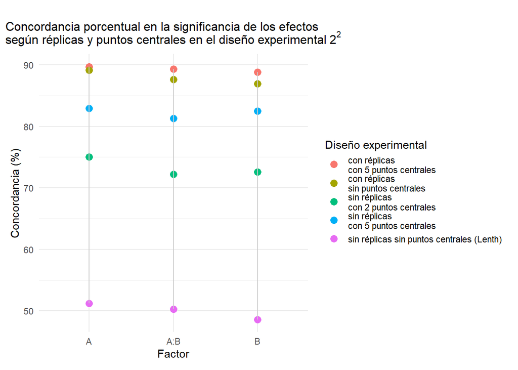

Figura 4.1

## 4.2 Diseño $2^3$

| Factores | Con réplicas con 5 puntos centrales Concordancia | Con réplicas con 5 puntos centrales Potencia | Con réplicas con 5 puntos centrales Error Tipo I | Con réplicas sin puntos centrales Concordancia | Con réplicas sin puntos centrales Potencia | Con réplicas sin puntos centrales Error Tipo I | Sin réplicas con 5 puntos centrales Concordancia | Sin réplicas con 5 puntos centrales Potencia | Sin réplicas con 5 puntos centrales Error Tipo I | Sin réplicas con 2 puntos centrales Concordancia | Sin réplicas con 2 puntos centrales Potencia | Sin réplicas con 2 puntos centrales Error Tipo I | Sin réplicas sin puntos centrales (Lenth) Concordancia | Sin réplicas sin puntos centrales (Lenth) Potencia | Sin réplicas sin puntos centrales (Lenth) Error Tipo I |
| --- | --- | --- | --- | --- | --- | --- | --- | --- | --- | --- | --- | --- | --- | --- | --- |
| A | 93.6 | 91.70 | 4.72 | 92.8 | 90.00 | 4.72 | 87.3 | 79.15 | 5.47 | 80.2 | 63.62 | 5.09 | 60.0 | 17.45 | 2.26 |
| B | 93.2 | 90.87 | 4.33 | 92.9 | 90.29 | 4.33 | 86.9 | 80.97 | 6.80 | 81.3 | 68.54 | 5.15 | 58.2 | 21.36 | 2.68 |
| C | 92.6 | 90.42 | 5.21 | 92.8 | 90.22 | 4.61 | 87.8 | 82.04 | 6.41 | 81.8 | 69.06 | 5.41 | 59.7 | 22.55 | 3.01 |
| A:B | 92.9 | 90.49 | 4.74 | 92.8 | 89.68 | 4.15 | 87.0 | 79.55 | 5.73 | 81.9 | 69.43 | 5.93 | 60.6 | 23.08 | 2.77 |
| A:C | 92.5 | 90.27 | 5.04 | 92.2 | 89.50 | 4.83 | 86.3 | 79.39 | 6.09 | 79.0 | 64.31 | 4.83 | 57.3 | 21.37 | 3.15 |
| B:C | 93.9 | 91.15 | 3.50 | 92.8 | 89.51 | 4.09 | 87.9 | 80.04 | 4.67 | 79.2 | 64.40 | 6.81 | 59.4 | 19.75 | 3.11 |
| A:B:C | 93.7 | 92.99 | 5.59 | 94.2 | 92.79 | 4.39 | 89.9 | 85.17 | 5.39 | 83.6 | 72.14 | 4.99 | 61.2 | 25.85 | 3.59 |

Tabla 4.2: Concordancia porcentual en la significancia de los efectos según réplicas y puntos centrales en el diseño experimental 2³

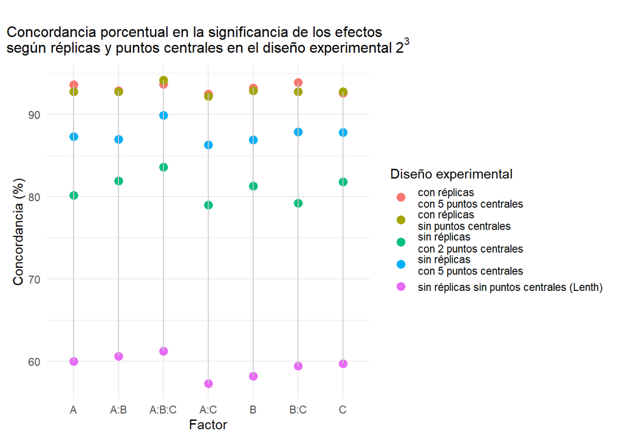

Figura 4.2

## 4.3 Diseño $2^4$

| Factores | Con réplicas con 5 puntos centrales Concordancia | Con réplicas con 5 puntos centrales Potencia | Con réplicas con 5 puntos centrales Error Tipo I | Con réplicas sin puntos centrales Concordancia | Con réplicas sin puntos centrales Potencia | Con réplicas sin puntos centrales Error Tipo I | Sin réplicas con 5 puntos centrales Concordancia | Sin réplicas con 5 puntos centrales Potencia | Sin réplicas con 5 puntos centrales Error Tipo I | Sin réplicas con 2 puntos centrales Concordancia | Sin réplicas con 2 puntos centrales Potencia | Sin réplicas con 2 puntos centrales Error Tipo I | Sin réplicas sin puntos centrales (Lenth) Concordancia | Sin réplicas sin puntos centrales (Lenth) Potencia | Sin réplicas sin puntos centrales (Lenth) Error Tipo I |
| --- | --- | --- | --- | --- | --- | --- | --- | --- | --- | --- | --- | --- | --- | --- | --- |
| A | 94.6 | 94.13 | 4.94 | 94.2 | 93.93 | 5.53 | 91.7 | 87.45 | 4.15 | 87.3 | 79.76 | 5.34 | 62.1 | 25.51 | 2.17 |
| B | 95.3 | 95.47 | 4.88 | 95.4 | 95.87 | 5.08 | 91.1 | 87.60 | 5.28 | 85.6 | 76.97 | 5.49 | 61.6 | 27.17 | 2.85 |
| C | 95.3 | 96.52 | 5.87 | 95.0 | 96.32 | 6.26 | 92.8 | 88.55 | 3.13 | 85.2 | 76.48 | 6.46 | 61.9 | 25.15 | 2.94 |
| D | 94.5 | 94.49 | 5.49 | 94.5 | 94.69 | 5.69 | 89.8 | 84.84 | 5.08 | 84.5 | 73.23 | 3.86 | 60.6 | 24.41 | 2.03 |
| A:B | 95.0 | 94.96 | 4.96 | 94.8 | 94.56 | 4.96 | 91.5 | 88.10 | 5.16 | 85.5 | 75.00 | 4.17 | 62.6 | 27.02 | 2.38 |
| A:C | 94.8 | 94.81 | 5.21 | 94.9 | 95.00 | 5.21 | 91.3 | 86.73 | 3.75 | 83.0 | 72.88 | 6.04 | 60.2 | 26.15 | 2.92 |
| B:C | 94.8 | 93.54 | 3.96 | 94.6 | 93.13 | 3.96 | 91.0 | 85.45 | 3.56 | 85.4 | 75.96 | 5.35 | 62.1 | 25.66 | 2.18 |
| A:D | 94.1 | 92.87 | 4.57 | 94.2 | 92.49 | 3.95 | 90.3 | 84.59 | 3.53 | 83.7 | 73.60 | 5.41 | 59.2 | 24.66 | 3.53 |
| B:D | 97.5 | 97.05 | 2.03 | 97.0 | 97.05 | 3.05 | 92.7 | 90.16 | 4.67 | 86.7 | 78.15 | 4.47 | 61.4 | 26.18 | 2.24 |
| C:D | 96.4 | 96.61 | 3.84 | 95.9 | 95.86 | 4.05 | 91.2 | 87.57 | 4.69 | 85.8 | 77.97 | 5.33 | 60.0 | 27.31 | 2.99 |
| A:B:C | 95.3 | 96.86 | 6.31 | 94.7 | 96.46 | 7.13 | 91.5 | 88.41 | 5.30 | 87.5 | 80.35 | 5.09 | 61.9 | 29.27 | 4.28 |
| A:B:D | 94.8 | 94.98 | 5.38 | 94.5 | 94.78 | 5.78 | 91.7 | 88.15 | 4.78 | 86.7 | 78.31 | 4.98 | 60.0 | 22.89 | 3.19 |
| A:C:D | 95.3 | 95.83 | 5.24 | 95.8 | 95.83 | 4.23 | 92.3 | 88.89 | 4.23 | 88.2 | 81.35 | 4.84 | 62.0 | 27.58 | 3.02 |
| B:C:D | 94.5 | 94.64 | 5.65 | 94.2 | 94.64 | 6.25 | 91.4 | 88.29 | 5.44 | 86.0 | 77.98 | 5.85 | 61.9 | 27.38 | 3.02 |
| A:B:C:D | 94.5 | 95.30 | 6.34 | 94.0 | 94.91 | 6.95 | 91.1 | 86.69 | 4.29 | 85.4 | 75.93 | 4.70 | 61.8 | 27.59 | 2.45 |

Tabla 4.3: Concordancia porcentual en la significancia de los efectos según réplicas y puntos centrales en el diseño experimental 2⁴

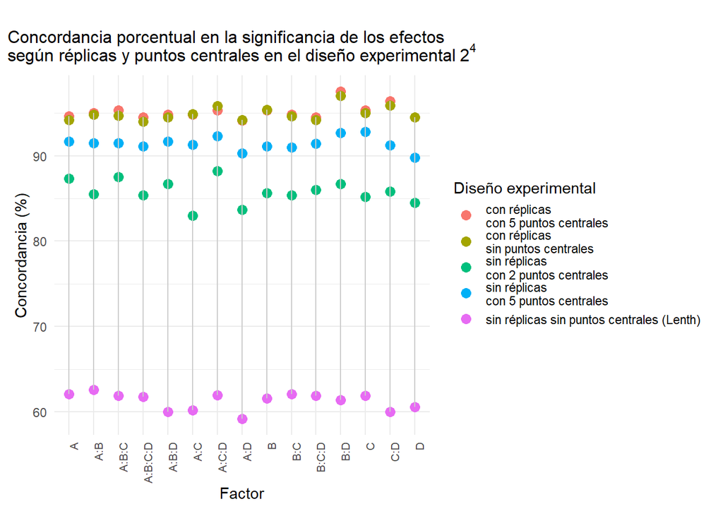

Figura 4.3

## 4.4 Diseño $2^5$

| Factores | Con réplicas con 5 puntos centrales Concordancia | Con réplicas con 5 puntos centrales Potencia | Con réplicas con 5 puntos centrales Error Tipo I | Con réplicas sin puntos centrales Concordancia | Con réplicas sin puntos centrales Potencia | Con réplicas sin puntos centrales Error Tipo I | Sin réplicas con 5 puntos centrales Concordancia | Sin réplicas con 5 puntos centrales Potencia | Sin réplicas con 5 puntos centrales Error Tipo I | Sin réplicas con 2 puntos centrales Concordancia | Sin réplicas con 2 puntos centrales Potencia | Sin réplicas con 2 puntos centrales Error Tipo I | Sin réplicas sin puntos centrales (Lenth) Concordancia | Sin réplicas sin puntos centrales (Lenth) Potencia | Sin réplicas sin puntos centrales (Lenth) Error Tipo I |
| --- | --- | --- | --- | --- | --- | --- | --- | --- | --- | --- | --- | --- | --- | --- | --- |
| A | 96.2 | 97.24 | 4.87 | 96.2 | 97.04 | 4.67 | 92.5 | 90.93 | 5.88 | 89.8 | 84.81 | 5.07 | 63.0 | 30.18 | 3.25 |
| B | 97.0 | 99.20 | 5.17 | 96.7 | 98.79 | 5.37 | 94.0 | 93.36 | 5.37 | 90.9 | 87.93 | 6.16 | 64.1 | 31.39 | 3.58 |
| C | 97.1 | 98.58 | 4.35 | 97.2 | 98.58 | 4.15 | 94.6 | 93.72 | 4.55 | 90.1 | 87.04 | 6.92 | 63.7 | 30.16 | 3.56 |
| D | 97.0 | 98.84 | 4.96 | 97.2 | 98.84 | 4.55 | 94.3 | 93.80 | 5.17 | 91.1 | 87.79 | 5.37 | 62.8 | 31.01 | 3.31 |
| E | 97.0 | 98.62 | 4.67 | 97.4 | 98.62 | 3.85 | 94.4 | 93.89 | 5.07 | 90.0 | 85.40 | 5.27 | 63.8 | 31.36 | 2.84 |
| A:B | 96.7 | 97.64 | 4.28 | 96.8 | 97.84 | 4.28 | 95.0 | 93.71 | 3.67 | 89.5 | 85.46 | 6.31 | 64.5 | 32.42 | 2.24 |
| A:C | 96.8 | 97.97 | 4.58 | 97.0 | 98.52 | 4.79 | 94.4 | 94.09 | 5.23 | 89.8 | 86.88 | 6.75 | 64.1 | 35.49 | 2.18 |
| B:C | 96.3 | 98.28 | 5.87 | 96.0 | 97.90 | 6.08 | 95.0 | 94.07 | 3.98 | 91.3 | 87.95 | 5.03 | 62.9 | 32.70 | 3.98 |
| A:D | 96.9 | 98.00 | 4.20 | 96.8 | 98.20 | 4.60 | 94.6 | 93.80 | 4.60 | 89.6 | 86.20 | 7.00 | 64.4 | 31.60 | 2.80 |
| B:D | 97.4 | 99.24 | 4.66 | 97.2 | 99.43 | 5.30 | 95.0 | 94.70 | 4.66 | 89.6 | 86.55 | 6.99 | 64.1 | 34.85 | 3.18 |
| C:D | 96.3 | 98.84 | 6.40 | 96.0 | 98.64 | 6.82 | 94.2 | 93.41 | 4.96 | 91.1 | 88.76 | 6.40 | 63.1 | 32.56 | 4.34 |
| A:E | 97.4 | 98.97 | 4.09 | 97.6 | 98.97 | 3.70 | 94.7 | 94.03 | 4.67 | 90.9 | 86.83 | 5.25 | 63.8 | 28.19 | 2.53 |
| B:E | 96.6 | 97.87 | 4.76 | 96.9 | 97.87 | 4.14 | 92.9 | 91.88 | 6.00 | 90.2 | 85.11 | 4.35 | 65.1 | 35.01 | 2.69 |
| C:E | 97.9 | 99.40 | 3.61 | 97.8 | 99.20 | 3.61 | 95.9 | 94.81 | 3.01 | 92.6 | 89.42 | 4.21 | 63.9 | 29.74 | 1.80 |
| D:E | 96.0 | 98.25 | 6.37 | 96.0 | 98.05 | 6.16 | 93.9 | 92.98 | 5.13 | 88.9 | 84.99 | 6.98 | 63.2 | 30.60 | 2.46 |
| A:B:C | 96.4 | 98.02 | 5.24 | 96.3 | 98.02 | 5.44 | 93.9 | 93.45 | 5.65 | 90.7 | 86.11 | 4.64 | 63.9 | 30.36 | 2.02 |
| A:B:D | 96.6 | 98.01 | 4.82 | 96.2 | 97.61 | 5.22 | 94.0 | 92.83 | 4.82 | 91.9 | 87.85 | 4.02 | 63.1 | 30.28 | 3.82 |
| A:C:D | 96.2 | 96.66 | 4.34 | 96.4 | 96.85 | 4.12 | 91.9 | 90.72 | 6.72 | 87.5 | 82.37 | 6.51 | 62.3 | 32.65 | 3.04 |
| B:C:D | 96.7 | 97.89 | 4.60 | 97.2 | 98.28 | 3.97 | 94.2 | 93.30 | 4.81 | 90.7 | 86.02 | 4.18 | 61.9 | 30.08 | 3.35 |
| A:B:E | 97.3 | 98.39 | 3.78 | 97.3 | 98.39 | 3.78 | 93.5 | 92.76 | 5.77 | 89.6 | 84.31 | 5.17 | 65.7 | 33.80 | 2.78 |
| A:C:E | 97.3 | 98.43 | 3.87 | 97.0 | 98.43 | 4.48 | 94.7 | 94.50 | 5.09 | 91.1 | 88.21 | 5.91 | 62.0 | 27.50 | 2.24 |
| B:C:E | 96.8 | 98.25 | 4.74 | 96.8 | 98.25 | 4.74 | 95.1 | 94.76 | 4.54 | 90.9 | 87.96 | 5.98 | 64.9 | 33.98 | 2.27 |
| A:D:E | 96.0 | 98.04 | 6.12 | 96.1 | 97.84 | 5.71 | 94.0 | 92.55 | 4.49 | 89.7 | 84.90 | 5.31 | 63.2 | 30.39 | 2.65 |
| B:D:E | 96.5 | 98.59 | 5.57 | 96.3 | 98.59 | 5.96 | 93.8 | 91.75 | 4.17 | 88.3 | 83.50 | 6.96 | 64.3 | 30.99 | 2.78 |
| C:D:E | 96.2 | 97.78 | 5.36 | 96.4 | 97.78 | 4.96 | 94.7 | 92.94 | 3.57 | 89.9 | 84.68 | 4.96 | 64.5 | 31.25 | 2.78 |
| A:B:C:D | 97.5 | 99.42 | 4.55 | 97.4 | 99.42 | 4.75 | 96.2 | 95.54 | 3.10 | 92.6 | 89.15 | 3.72 | 63.5 | 31.01 | 1.86 |
| A:B:C:E | 96.4 | 97.60 | 4.79 | 96.3 | 97.60 | 4.99 | 93.7 | 92.18 | 4.79 | 89.8 | 84.57 | 4.99 | 65.2 | 33.07 | 2.79 |
| A:B:D:E | 97.2 | 99.22 | 4.91 | 96.9 | 99.02 | 5.32 | 95.9 | 96.28 | 4.50 | 91.2 | 87.67 | 5.11 | 63.7 | 32.29 | 3.48 |
| A:C:D:E | 97.3 | 98.50 | 4.07 | 97.2 | 98.50 | 4.28 | 94.1 | 92.87 | 4.50 | 89.5 | 85.55 | 6.00 | 63.3 | 33.77 | 3.00 |
| B:C:D:E | 96.2 | 97.44 | 5.07 | 95.9 | 97.24 | 5.48 | 93.5 | 91.91 | 4.87 | 89.8 | 84.62 | 4.87 | 64.0 | 32.94 | 4.06 |
| A:B:C:D:E | 96.8 | 98.64 | 5.15 | 96.6 | 98.64 | 5.57 | 95.3 | 93.79 | 3.09 | 89.7 | 85.05 | 5.36 | 63.5 | 31.65 | 2.68 |

Tabla 4.4: Concordancia porcentual en la significancia de los efectos según réplicas y puntos centrales en el diseño experimental 2⁵

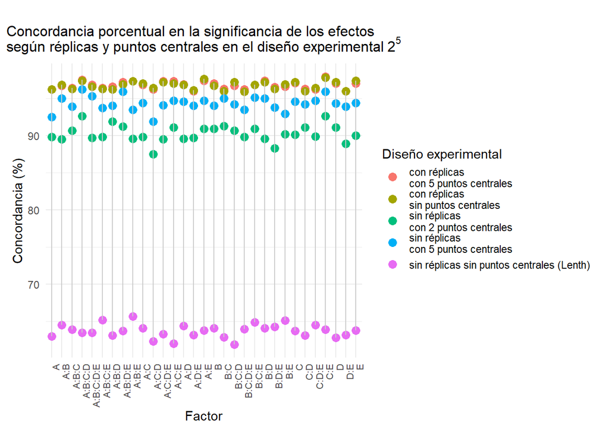

Figura 4.4

## 4.5 Evaluación del ECM por medidas repetidas para todos los tratamientos

### 4.5.1 Análisis descriptivo de los ECM por diseño

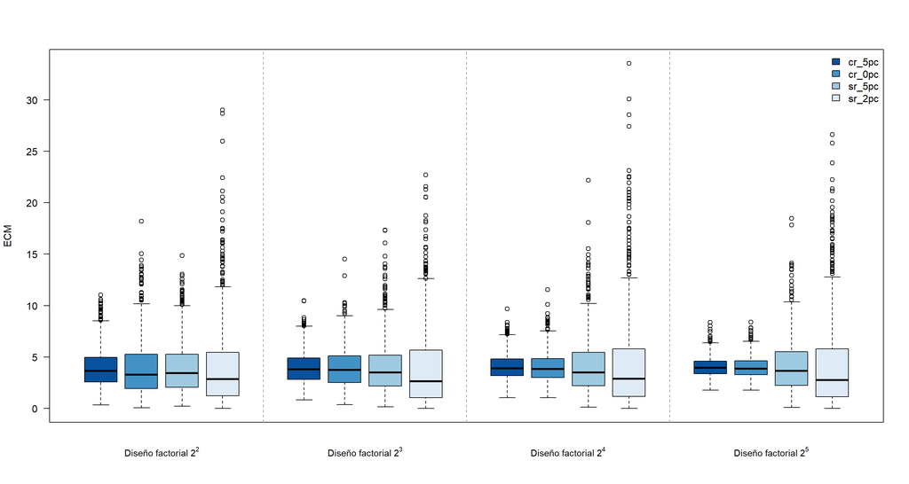

Figura 4.5: Análisis descriptivo de los ECM por diseño factorial

| Diseño | T² | F_calculado | F_crítico | Decisión |
| --- | --- | --- | --- | --- |
| Diseño factorial 2² | 0.27 | 0.09 | 2.61 | No se rechaza H₀ |
| Diseño factorial 2³ | 2.67 | 0.89 | 2.61 | No se rechaza H₀ |
| Diseño factorial 2⁴ | 2.21 | 0.74 | 2.61 | No se rechaza H₀ |
| Diseño factorial 2⁵ | 4.96 | 1.65 | 2.61 | No se rechaza H₀ |

Tabla 4.5

### 4.5.3 Matriz de contrastes generales de interés $C_2$

| Diseño | T² | F_calculado | F_crítico | Decisión |
| --- | --- | --- | --- | --- |
| Diseño factorial 2² | 4,659.31 | 1,549.99 | 2.61 | Se rechaza H₀ |
| Diseño factorial 2³ | 6,901.92 | 2,296.04 | 2.61 | Se rechaza H₀ |
| Diseño factorial 2⁴ | 10,795.48 | 3,591.29 | 2.61 | Se rechaza H₀ |
| Diseño factorial 2⁵ | 19,226.23 | 6,395.91 | 2.61 | Se rechaza H₀ |

Tabla 4.6

Dado que, al evaluar la matriz de contrastes, se rechazó la hipótesis nula, es decir, al menos hay uno de los contrastes que es diferente de 0, resulta necesario analizar cada contraste de manera individual, obteniéndose los siguientes resultados:

#### 4.5.3.1 Contraste $C_{21} =$ (-1, -1, 1, 1)

| Diseño | T² | F_calculado | F_crítico | Decisión |
| --- | --- | --- | --- | --- |
| Diseño factorial 2² | 0.10 | 0.03 | 2.61 | No se rechaza H₀ |
| Diseño factorial 2³ | 0.20 | 0.07 | 2.61 | No se rechaza H₀ |
| Diseño factorial 2⁴ | 2.13 | 0.71 | 2.61 | No se rechaza H₀ |
| Diseño factorial 2⁵ | 1.16 | 0.38 | 2.61 | No se rechaza H₀ |

Tabla 4.7

#### 4.5.3.2 Contraste $C_{22} =$ (-1, 1, 1, 1)

| Diseño | T² | F_calculado | F_crítico | Decisión |
| --- | --- | --- | --- | --- |
| Diseño factorial 2² | 2,525.00 | 839.98 | 2.61 | Se rechaza H₀ |
| Diseño factorial 2³ | 2,661.76 | 885.48 | 2.61 | Se rechaza H₀ |
| Diseño factorial 2⁴ | 2,063.87 | 686.58 | 2.61 | Se rechaza H₀ |
| Diseño factorial 2⁵ | 2,022.54 | 672.83 | 2.61 | Se rechaza H₀ |

Tabla 4.8

#### 4.5.3.3 Contraste $C_{23} =$ (1, -1, 0, 0)

| Diseño | T² | F_calculado | F_crítico | Decisión |
| --- | --- | --- | --- | --- |
| Diseño factorial 2² | 0.06 | 0.02 | 2.61 | No se rechaza H₀ |
| Diseño factorial 2³ | 0.17 | 0.06 | 2.61 | No se rechaza H₀ |
| Diseño factorial 2⁴ | 1.68 | 0.56 | 2.61 | No se rechaza H₀ |
| Diseño factorial 2⁵ | 2.75 | 0.92 | 2.61 | No se rechaza H₀ |

Tabla 4.9

Dı́az Monroy, Luis Guillermo, y Rivera Morales Mario Alfonso. 2012. *Análisis estadı́stico de datos multivariados*. Universidad Nacional de Colombia.

Volver arriba